# Data 605 HW7

William Jasmine

2023-03-08

```r
library(ggplot2)
```

# Question 1

**Description:**

Let $X_1, X_2,..., X_n$ be n mutually independent random variables, each of which is uniformly distributed on the integers from 1 to $k$. Let $Y$ denote the minimum of the $X_i$’s. Find the distribution of $Y$.

**Solution:**

There are $k$ possible outcomes for each of the random variables $X_i$s. Thus, the number of ways we can assign values to each of them is:

$$\sum_{i=1}^n k = k^n$$

Let’s say now that the minimum of each $X_i$ is 1, i.e $Y$=1. The number of ways this can happen will then be the total number of outcomes minus the number of ways in which all the of the $X_i$s are greater than 1. Mathematically, this would be equivalent to $k^n - (k-1)^n$, where the $(k-1)^n$ term represents all the outcomes in which none of the $X_is$ are equal to 1. Similarly, if $Y=2$, the number of possible outcomes is $k^n - (k-2)^n - (k^n - (k-1)^n)$ where $(k-2)^n$ represents all the outcomes in which none of the $X_is$ are equal to 2. Continuing this pattern we see that in general, the number of outcomes in which $Y=j$ is: $(k−j+1)^n−(k−j)^n$. Thus, for a given $Y$, the probability $P(Y)$ is equal to

$$P(Y) = \frac{(k−j+1)^n−(k−j)^n}{k^n}$$

In order to test the above probability distribution, the code below simulates the the described experiment 10,000 times where $k=n=5$. This produces a computational probability distribution for $Y$, that can be compared to our hypothetical one above.

```r
trials <- 10000
n <- 5
k <- 5
xs <- seq(1, k)
Ys <- c()
Ps <- c()
Ps_expected <- c()

for (i in 1:trials){
  xis = sample(1:k, size=n,replace=TRUE)
  Y <- min(xis)
  Ys[i] = Y
  for (j in 1:k){
    Ps[j] <- length(which(Ys == j)) / 10000
    Ps_expected[j] <- (((k - j + 1) ** n) - ((k - j) ** n)) / (k ** n)
  }
}

plt_data <- data.frame(xs, Ps, Ps_expected)
plt_data
```

```
##   xs     Ps Ps_expected
## 1  1 0.6697     0.67232
## 2  2 0.2516     0.24992
## 3  3 0.0688     0.06752
## 4  4 0.0096     0.00992
## 5  5 0.0003     0.00032
```

We see from the above that the computational probabilities are quite close to what our equation for $P(Y)$ predicts. They are plotted together below:

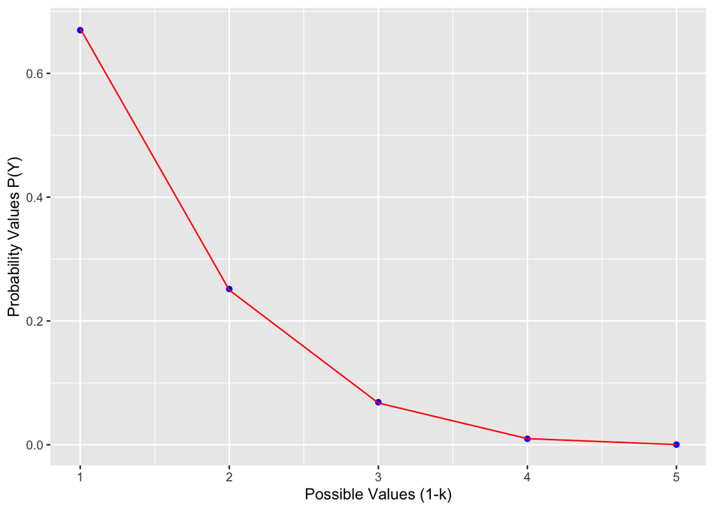

```r
ggplot(data = plt_data) +
  geom_point(aes(x=xs, y=Ps), color='blue') +
  geom_line(aes(x=xs, y=Ps_expected), color='red') +
  xlab("Possible Values (1-k)") +
  ylab("Probability Values P(Y)")
```

# Question 2

**Description:** Your organization owns a copier (future lawyers, etc.) or MRI (future doctors). This machine has a manufacturer’s expected lifetime of 10 years. This means that we expect one failure every ten years. What is the probability that the machine will fail after 8 years?

## Model as a Geometric Distribution

To model as a geometric, we can use the fact that we expect the MRI machine to fail after 10 years. The expectation value for a geometric distribution is given as $E(X) = \frac{1}{p}$. Plugging in, we see that we can model this situation as using a geometric model in which $p$=0.1.

The geometric distribution gives the probability $P(x, p)$ that the first occurrence of success requires $x$ independent trials, each with success probability $p$. It is written as and is just the result of multiplying together independent probabilities:

$$\begin{equation}
P(x, p) = (1-p)^{x-1}p
\end{equation}$$

Thus, in this case the probability that the machine fails after 8 years is equal to 1 minus the probability that it fails in the first 8 years:

$$\begin{align}
P(x > 8, p) &= 1 - \sum_{x=1}^8 (1-p)^{x-1}p \\
P(x > 8, 0.1) &= 1 - \sum_{x=1}^8 (1-0.1)^{x-1}(0.1) \\
P(x > 8, 0.1) &\approx 0.43
\end{align}$$

The code to actually produce the answer shown above is provided below:

```r
#P <- pgeom(7, 0.1) # also works, no need for loop
p <- 0.1
p_geom <- 0

for (i in 1:8){
  tmp = ((1 - p)^(i-1))*p
  # tmp = dgeom(i-1, p) # also works
  p_geom <- p_geom + tmp
}

p_geom <- 1 - p_geom
p_geom
```

```
## [1] 0.4304672
```

The standard deviation of a geometric distribution can be given by $\sigma = \frac{\sqrt{(1-p)}}{p}$. In this case, we have $\sigma = \frac{\sqrt{0.9}}{0.1} = 9.486833$.

## Model as an Exponential Distribution

To model as a exponential, we can use the fact that we expect the MRI machine to fail after 10 years. The expectation value for an exponential distribution is given as $E(X) = \frac{1}{\lambda}$. Plugging in, we see that we can model this situation as using a geometric model in which $\lambda$=0.1.

The exponential distribution is written as describes the probability $P(x,\lambda)$ of an event occurring after $x$ amount of time. It consists of a rate factor $\lambda$, which is equal to $\frac{1}{\mu}$ where $\mu$ is the average time it takes for the event to occur:

$$\begin{equation}
P(x,\lambda) =
\begin{cases}
0, & x < 0 \\
\lambda e^{-\lambda x}, & x \geq0
\end{cases}
\end{equation}$$

To determine the probability that the MRI will fail after 8 years we must compute:

$$\begin{align}
P(x>8,\frac{1}{10}) &= 1 - \int_{x=0}^8 \frac{1}{10}
e^{-\frac{1}{10} x} \\
P(x>8,\frac{1}{10}) &\approx 0.45
\end{align}$$

Note the integral as opposed to a sum, since the variable of interest in this case (failure time of the MRI) is continuous. The cell below computes the above using the R `integrate` function:

```r
# pexp(8, 0.1, lower.tail = FALSE) # should give the same result
integrand <- function(x) {.1 * exp(-.1 * x)}
p_exp <- 1 - integrate(integrand, lower = 0, upper = 8)$value
p_exp
```

```
## [1] 0.449329
```

## Model as an Binomial Distribution

To model as a binomial, we can use assume that that probability of the machine failing each year is $p$, and that we receive 0 failures in 8 years. The expectation value of a binomial distribution is given as $E(X) = np$, and since we know that we expect the machine to fail once in 10 years, we can plug in to determine that $1 = 10 \cdot p \Rightarrow p =\frac{1}{10}$.

We can use the binomial distribution to determine $P(x,n,p)$ which is the probability of receiving $x$ failures in $n$ years:

$$\begin{equation}
P(x,n,p) = {n \choose x}p^x(1-p)^{n-x}
\end{equation}$$

Thus, plugging in $x=0$ and $n=8$ we have:

$$\begin{align}
P(0, 8, 0.1) &= {8 \choose 0}0.1^0(1-0.1)^{8-0} \\
P(0, 8, 0.1) &\approx 0.43
\end{align}$$

The value above is determined using R in the cell below:

```r
# pbinom(0, 8, 0.1) # will give the same answer
p_binom <- choose(8, 0) * (0.1 ** 0) * ((1-0.1) ** (8-0))
p_binom
```

```
## [1] 0.4304672
```

The standard deviation of a binomial distribution is given as $\sigma = \sqrt{np(1-p)} \approx 0.85$.

## Model as a Poisson

To model as a poisson, we can assume that the mean rate of failure is 1 MRI every 10 years. This means we would expect 0.8 machines to fail every 8 years.

The poisson distribution says that given a mean rate of success (or in this case, failure) $\lambda$, we can determine the probability $P(x, \lambda)$ of $x$ successes via the following:

$$\begin{equation}
P(x, \lambda) = \frac{e^{-\lambda}\lambda^x}{x!}
\end{equation}$$

If we are looking for the probability that 0 machines fail every 8 years, then we can plug in the following:

$$\begin{align}
P(0, 0.8) &= \frac{e^{-0.8}\cdot 10^0}{0!} \\
&\approx 0.45
\end{align}$$

The value above is determined using R in the cell below:

```r
# ppois(0, 0.8) # will provide the same answer
p_pois <- (exp(-0.8) * (10**0)) / factorial(0)
p_pois
```

```
## [1] 0.449329
```

The standard deviation of a poisson distribution is given as $\sigma=\sqrt{\lambda}=\sqrt{0.8}\approx 0.89$.

## Summary

The following table summarizes the result from each modelling methodology to answer the question, what is the probability that the machine will fail after 8 years?

```r
models <- c('Geometric', 'Binomial', 'Exponential', 'Poisson')
probs <- c(p_geom, p_binom, p_exp, p_pois)
data.frame(models, probs)
```

```
##        models     probs
## 1   Geometric 0.4304672
## 2    Binomial 0.4304672
## 3 Exponential 0.4493290
## 4     Poisson 0.4493290
```